# Лабораторная работа № 2. Первоначальная настройка git

НПИбд-03-25

Author

Чжу Ино

Published

2026-10-14

# 1 Цель работы

Изучить идеологию и применение средств контроля версий. Освоить умения по работе с git.

# 2 Задачи

1. Установить git и gh.
2. Выполнить базовую настройку git.
3. Создать ключи SSH.
4. Создать ключи PGP.
5. Настроить GitHub.
6. Добавить SSH-ключ в GitHub.
7. Настроить gh.
8. Создать репозиторий курса на основе шаблона.
9. Настроить каталог курса.

# 3 Установка программного обеспечения

Выполнена установка git и gh:

```bash
sudo dnf -y install git
sudo dnf -y install gh
```

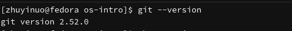

Figure 1: Версия git

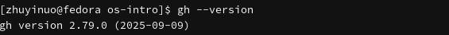

Figure 2: Версия gh

# 4 Базовая настройка git

```bash
git config --global user.name "Чжу Ино"
git config --global user.email "1132258331@rudn.ru"
git config --global core.quotepath false
git config --global init.defaultBranch master
git config --global core.autocrlf input
git config --global core.safecrlf warn
```

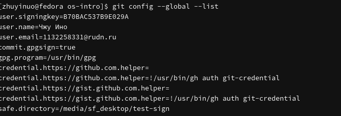

Figure 3: Глобальная конфигурация git

# 5 Создание ключей SSH

Сгенерированы ключи RSA (4096 бит) и Ed25519.

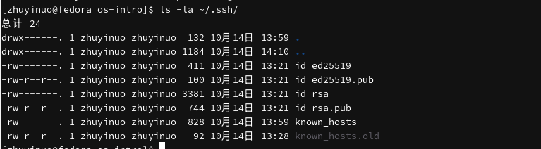

Figure 4: Список SSH-ключей

Содержимое открытого ключа Ed25519:

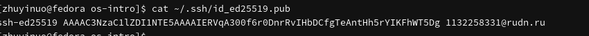

Figure 5: Открытый ключ SSH

# 6 Создание ключей PGP

Сгенерирован PGP-ключ (RSA 4096).

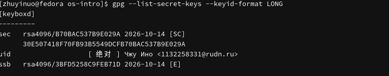

Figure 6: Список PGP-ключей

Экспорт открытого PGP-ключа:

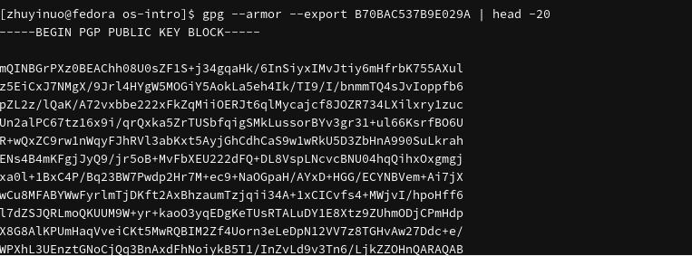

Figure 7: Открытый PGP-ключ

# 7 Настройка GitHub

SSH-ключ добавлен в учётную запись GitHub:

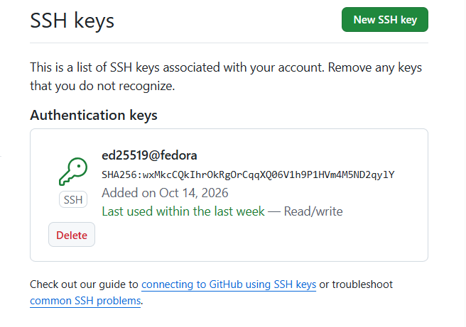

Figure 8: SSH-ключ на GitHub

PGP-ключ добавлен в учётную запись GitHub:

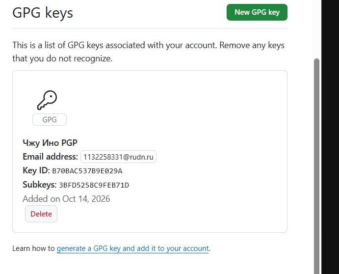

Figure 9: PGP-ключ на GitHub

Настроены автоматические подписи коммитов:

```bash
git config --global user.signingkey B70BAC537B9E029A
git config --global commit.gpgsign true
git config --global gpg.program $(which gpg)
```

# 8 Настройка gh

Выполнена авторизация gh:

```bash
gh auth login
```

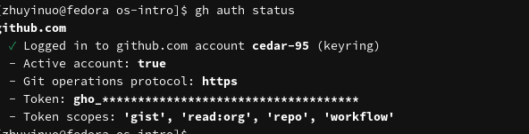

Figure 10: Статус gh

# 9 Шаблон для рабочего пространства

## 9.1 Создание репозитория курса

Создан репозиторий `study_2026-2_os-intro` на основе шаблона:

```bash
mkdir -p ~/work/study/2026-2/
cd ~/work/study/2026-2/
gh repo create study_2026-2_os-intro --template=yamadharma/course-directory-student-template --public
git clone --recursive git@github.com:cedar-95/study_2026-2_os-intro.git os-intro
```

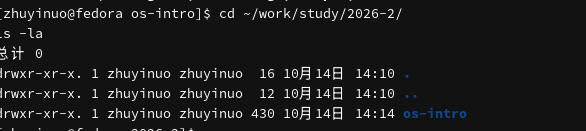

Figure 11: Клонирование репозитория

## 9.2 Настройка каталога курса

```bash
cd ~/work/study/2026-2/os-intro
echo os-intro > COURSE
make prepare
```

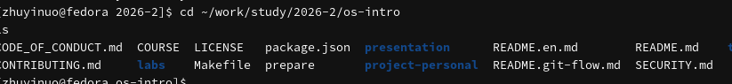

Figure 12: Структура курса

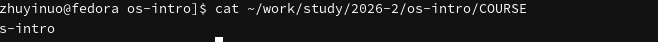

Figure 13: Файл COURSE

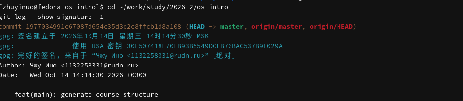

Figure 14: Подписанный коммит

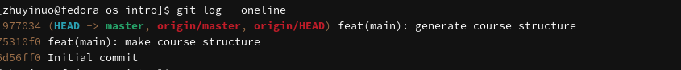

Figure 15: История коммитов

[figure not shown]

Figure 16: Репозиторий на GitHub

# 10 Выводы

В ходе лабораторной работы изучена идеология систем контроля версий. Освоены навыки работы с git: базовая настройка, создание ключей SSH и PGP, настройка GitHub, авторизация gh, создание репозитория курса на основе шаблона.

# 11 Контрольные вопросы

**1. Что такое системы контроля версий (VCS) и для решения каких задач они предназначаются?**

VCS — системы, позволяющие фиксировать изменения в проекте, совмещать изменения разных участников, откатывать к предыдущим версиям.

**2. Объясните понятия VCS: хранилище, commit, история, рабочая копия.**

- Хранилище — место хранения всех версий проекта.
- Commit — зафиксированное изменение.
- История — последовательность коммитов.
- Рабочая копия — локальная версия файлов пользователя.

**3. Чем отличаются централизованные и децентрализованные VCS?**

- Централизованные (CVS, Subversion) — единый сервер.
- Децентрализованные (Git, Bazaar, Mercurial) — у каждого полная копия репозитория.

**4. Опишите действия с VCS при единоличной работе с хранилищем.**

Получение версии → изменения → фиксация → размещение новой версии в хранилище.

**5. Опишите порядок работы с общим хранилищем VCS.**

Получение обновлений → работа в локальной ветке → фиксация изменений → отправка в центральный репозиторий.

**6. Каковы основные задачи, решаемые инструментальным средством git?**

Управление версиями, ветвление, слияние, работа с удалёнными репозиториями.

**7. Назовите и дайте краткую характеристику командам git.**

- `git init` — создание репозитория.
- `git add` — добавление файлов в индекс.
- `git commit` — фиксация изменений.
- `git push` — отправка в удалённый репозиторий.
- `git pull` — получение изменений.
- `git status` — статус.
- `git diff` — просмотр изменений.
- `git branch` — работа с ветками.
- `git checkout` — переключение веток.
- `git merge` — слияние.

**8. Приведите примеры использования при работе с локальным и удалённым репозиториями.**

Локальный: `git init`, `git add`, `git commit`. Удалённый: `git remote add`, `git push`, `git pull`.

**9. Что такое и зачем могут быть нужны ветви (branches)?**

Ветви — параллельные линии разработки. Позволяют вести работу над несколькими функциями одновременно.

**10. Как и зачем можно игнорировать некоторые файлы при commit?**

Файл `.gitignore` содержит шаблоны игнорируемых файлов (временные, объектные, кэш). Нужно, чтобы в репозиторий не попадали лишние файлы.

# 12 Список литературы

1. Чакон С., Штрауб Б. Git для профессионального программиста. — СПб. : Питер, 2016.
2. Лоэл Д., Маккалоу М. Pro Git. — Apress, 2014.
3. Колисниченко Д. Н. Самоучитель системного администратора Linux. — БХВ-Петербург, 2011.